# Project P2

# **IE 423 Quality Engineering**

## **Project Part 2**

### **Part 1**

```r
setwd('/Users/kadir/Downloads/')
library("jpeg", lib.loc="~/R/win-library/3.5")
library("imager", lib.loc="~/R/win-library/3.5")
library("qcc", lib.loc="~/R/win-library/3.5")
imgg <- readJPEG('group_6.jpg')
img<-imgg
img1<-as.cimg(imgg)
imgg <- grayscale(img1)
imgold <-imgg
```

We stored the original image under the name ‘imgold’

### **Part 1.a**

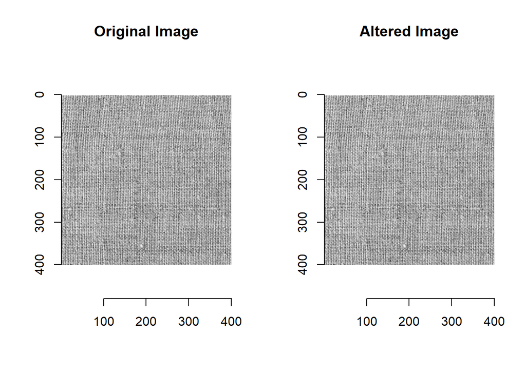

```r
for(i in 1:400){
   meanrow <- mean(imgg[,i,,])
   sdrow <- sd(imgg[,i,,])
   uplim <- qnorm(0.9995,meanrow,sdrow)
   lowlim <- qnorm(0.0005,meanrow,sdrow)
   for(j in 1:400){
     if(imgg[j,i,,] <= lowlim){
      imgg[j,i,,] = 0
     }
     if(imgg[j,i,,] >= uplim){
       imgg[j,i,,] = 0
     }
   }
}

imgrow <- imgg
par(mfrow=c(1,2))
plot(imgold, main ="Original Image")
plot(imgrow, main ="Altered Image")
```

Each row of the image was evaluated wihin itself. The upper and lower limits were chosen so that 0.001 of the observations stayed out of the limits. Then, the values of the pixels that were out of the limits are changed to zero (the pixels’ colours were made black). As can be seen there is no much difference betwwen two images. This shows that there is not a lot of pixels tht are out of the boundaries thus they are not black.

### **Part 1.b**

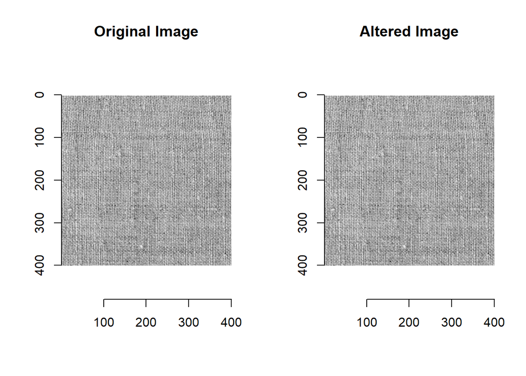

```r
imgg <- imgold
for(i in 1:400){
  meancol <- mean(imgg[i,,,])
  sdcol <- sd(imgg[i,,,])
  uplim <- qnorm(0.9995,meancol,sdcol)
  lowlim <- qnorm(0.0005,meancol,sdcol)
  for(j in 1:400){
    if(imgg[i,j,,] <= lowlim){
      imgg[i,j,,] = 0
    }
    if(imgg[i,j,,] >= uplim){
      imgg[i,j,,] = 0
    }
  }

}

imgcol <- imgg
par(mfrow=c(1,2))
plot(imgold, main ="Original Image")
plot(imgcol, main ="Altered Image")
```

Here we did the same thing we did for the rows. We chose our upper and lower limits so that 0.001 of the observations would be out of boundaries. Again there is not much difference between the original and the altered version.

### **Part 2**

```r
require(data.table)
```

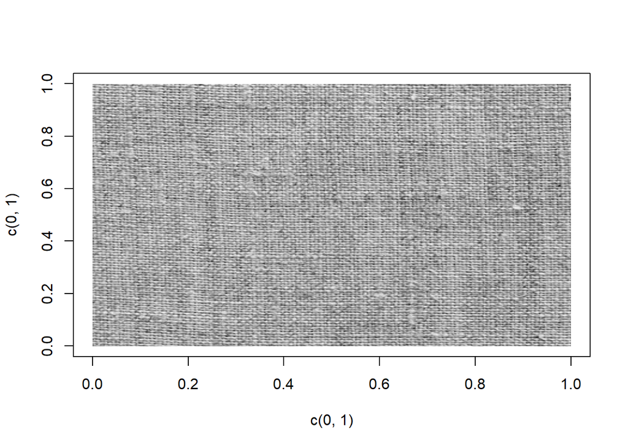

```r
bar<- img[,,1]+img[,,2]+img[,,3]
bar <- bar/max(bar)
plot(c(0,1),c(0,1),t='n')
rasterImage(bar, 0,0,1,1)
```

```r
memory.limit()
```

```
## [1] 8080
```

```r
memory.limit(size=56000)
```

```
## [1] 56000
```

CREATE PATCHES

We create r matrix. Rows of this matrix represent patches. Columns of this matrix represent variables.

```r
r<-matrix(0,122500,2601)
for (i in 26:375)
{
   for (j in 26:375)
    {
        for (k in 1:51)
        {
            for (l in 1:51)
            {
                 r[(i-1)*350+j-8775,(k-1)*51+l] <-bar[i + k - 26, j + l - 26]
             }
        }
    }
}
table<-data.table(r)
remove(r)
```

CREATE MODEL

```r
model<-lm(V1301~.,data=table)
table[,predicted:=predict(model,table)]
table[,residual:=table$V1301-predicted]
```

CONTROL RESIDUALS ARE NORMALLY DISTRIBUTED

Residuals are normally distributed.

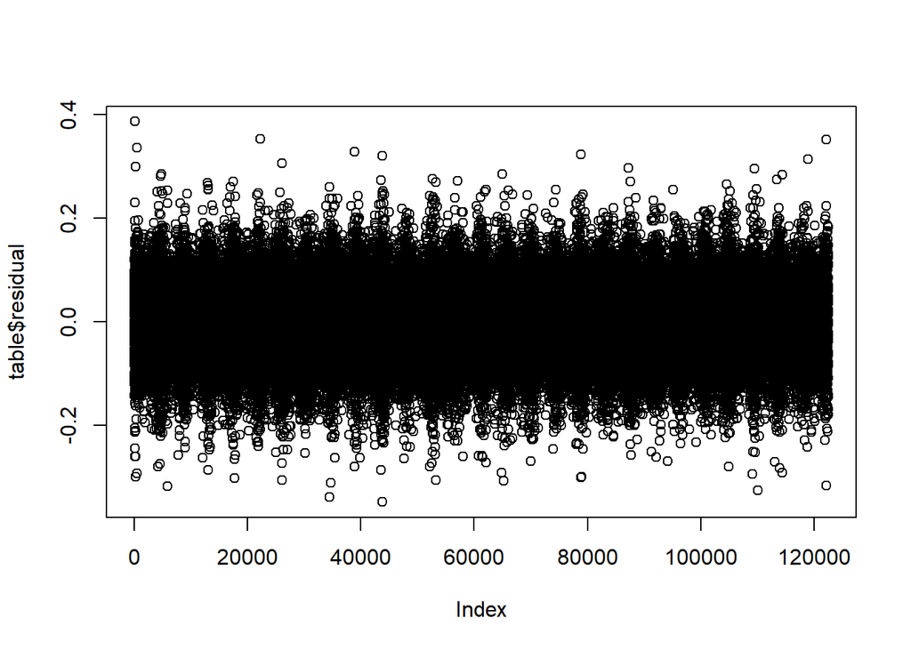

```r
plot(table$residual)
```

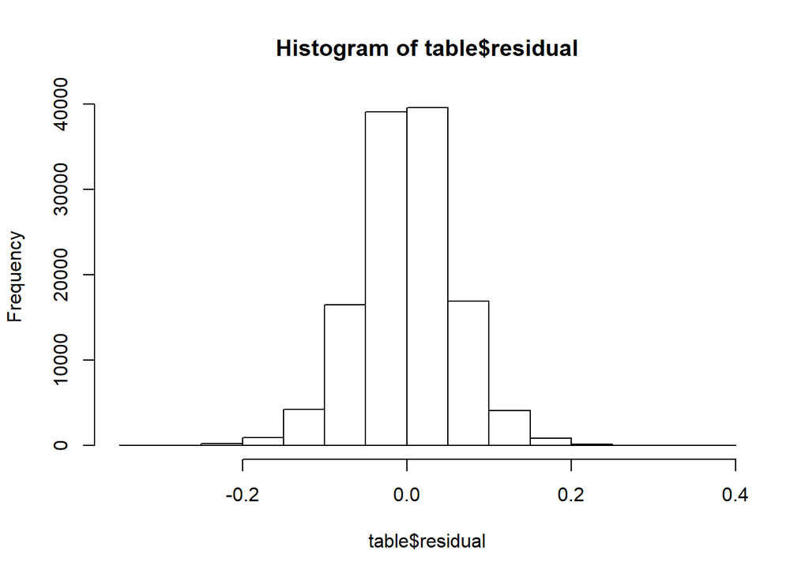

```r
hist(table$residual)
```

```r
mean(table$residual)
```

```
## [1] 9.776471e-16
```

```r
sd(table$residual)
```

```
## [1] 0.05865037
```

CREATE CHART

We use 3 sigma level to create chart.

```r
UCL=mean(table$residual)+3*sd(table$residual)
LCL=mean(table$residual)-3*sd(table$residual)
newbar <-matrix(0,350,350)
 for (i in 26:375)
       {
         for (j in 26:375)
               {
                    newbar[i-25,j-25]<-bar[i,j]
                 }
         }
 residual<-matrix(0,350,350)
  for (i in 26:375)
      {
           for (j in 26:375)
               {
                            residual[i-25,j-25]  <-table$residual[(i-1)*350+j-8775]
                 }
       }

 for (i in 1:350)
    {
          for (j in 1:350)
              {
                               if(residual[i,j]>UCL){
                               newbar[i,j]<-0;}
                               else if(residual[i,j]<LCL){
                               newbar[i,j]<-0;}

                   }
      }
```

We find the residuals are out of controls. After finding those residuals (corresponding to certain pixels), we change the value of these pixels to zero (i.e. black color). We display the new image and original image in a plot.

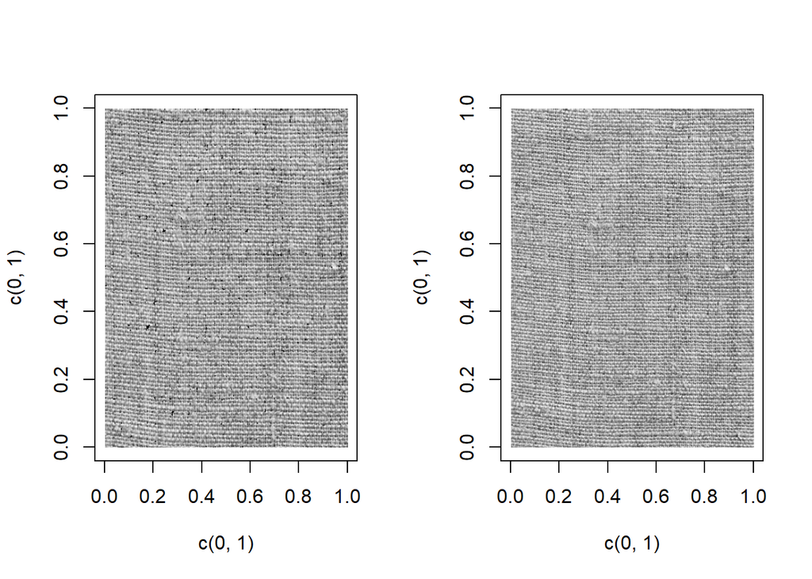

```r
par(mfrow=c(1,2))
plot(c(0,1),c(0,1),t='n')
rasterImage(newbar, 0,0,1,1)
plot(c(0,1),c(0,1),t='n')
rasterImage(bar, 0,0,1,1)
```

There are better ways to handle the problem of autocorrelation. We should focus on multicollinearity. We remove highly correlated predictors from the model to fix it. Also, we use Partial Least Squares Regression (PLS) or Principal Components Analysis, regression methods that cut the number of predictors to a smaller set of uncorrelated components.